신록예찬's 블로그

# (노트) First CNN

완성 (env:2021bda)

Aug 25, 2021 • 신록예찬 • 1 min read

파이토치

- ref
- check jupyter version
- install pkgs
- import
- download data (cat and dog images)
- my first model
- 오답분석
- 진짜 잘되는게 맞는지?

### ref

`-` https://ipywidgets.readthedocs.io/en/stable/user_install.html

### check jupyter version

```python
! jupyter --version
```

```
jupyter core     : 4.7.1
jupyter-notebook : 6.4.3
qtconsole        : 5.1.1
ipython          : 7.26.0
ipykernel        : 6.2.0
jupyter client   : 6.1.12
jupyter lab      : 3.1.8
nbconvert        : 5.6.1
ipywidgets       : 7.6.3
nbformat         : 5.1.3
traitlets        : 5.0.5
```

주피터랩 버전이 3.0>0 이상임

### install pkgs

```python
#!pip install graphviz
#!conda install -c conda-forge jupyterlab_widgets -y
#!conda install -c conda-forge ipywidgets -y
#!conda install -c conda-forge nodejs -y
```

### import

```python
from fastai.vision.all import *
```

### download data (cat and dog images)

```python
path=untar_data(URLs.PETS)/'images'
```

```python
path
```

```
Path('/home/cgb4/.fastai/data/oxford-iiit-pet/images')
```

```python
path.ls()
```

```
(#7395) [Path('/home/cgb4/.fastai/data/oxford-iiit-pet/images/staffordshire_bull_terrier_106.jpg'),Path('/home/cgb4/.fastai/data/oxford-iiit-pet/images/english_cocker_spaniel_170.jpg'),Path('/home/cgb4/.fastai/data/oxford-iiit-pet/images/leonberger_5.jpg'),Path('/home/cgb4/.fastai/data/oxford-iiit-p…
```

> - `URLs.PETS`는 그냥 https://s3.amazonaws.com/fast-ai-imageclas/oxford-iiit-pet.tgz 가 저장된 스트링.. > - untar_data()는 fastai에서 제공하는 함수. zip파일을 다운받을 수 있는 URL주소, 혹은 zip파일이 위치한 경로를 str으로 받으면 (1) 압축을 풀고 (2) PosixPath Type의 인스턴스를 반환한다.
> - PosixPath는 파이썬 자체에서 제공되는 자료형인듯. (이런건 [공식문서] (https://docs.python.org/ko/3/library/pathlib.html)가 잘 정리되어있다.)
> - PosixPath 타입은 `/` operator를 통해 문자열과 결합할 수 있음.
> - PosixPath 타입은 `ls` method를 통하여 path에 저장된 파일들의 목록을 출력할 수 있음

```python
files = get_image_files(path)
files
```

```
(#7390) [Path('/home/cgb4/.fastai/data/oxford-iiit-pet/images/staffordshire_bull_terrier_106.jpg'),Path('/home/cgb4/.fastai/data/oxford-iiit-pet/images/english_cocker_spaniel_170.jpg'),Path('/home/cgb4/.fastai/data/oxford-iiit-pet/images/leonberger_5.jpg'),Path('/home/cgb4/.fastai/data/oxford-iiit-p…
```

```python
files[0],files[1],files[2],files[3],files[4]
```

```
(Path('/home/cgb4/.fastai/data/oxford-iiit-pet/images/staffordshire_bull_terrier_106.jpg'),
 Path('/home/cgb4/.fastai/data/oxford-iiit-pet/images/english_cocker_spaniel_170.jpg'),
 Path('/home/cgb4/.fastai/data/oxford-iiit-pet/images/leonberger_5.jpg'),
 Path('/home/cgb4/.fastai/data/oxford-iiit-pet/images/shiba_inu_209.jpg'),
 Path('/home/cgb4/.fastai/data/oxford-iiit-pet/images/american_pit_bull_terrier_104.jpg'))
```

```python
def label_func(f):
    if f[0].isupper():
        return 'cat'
    else:
        return 'dog'
```

```python
label_func('asdf')
```

```
'dog'
```

```python
dls = ImageDataLoaders.from_name_func(path, files, label_func, item_tfms=Resize(224)) ## 데이터로더는 좀더 탐구필요
# dls = ImageDataLoaders.from_name_func(
#     path, get_image_files(path),valid_pct=0.2, seed=42,
#     label_func=is_cat, item_tfms=Resize(224))
```

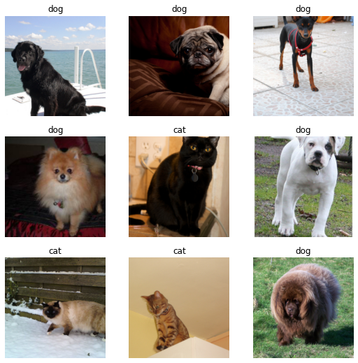

```python
dls.show_batch(max_n=9) # 실행할때마다 결과바뀜
```

### my first model

```python
learn=cnn_learner(dls,resnet34, metrics=error_rate)
```

```python
learn.fine_tune(1)
```

| epoch | train_loss | valid_loss | error_rate | time |
| --- | --- | --- | --- | --- |
| 0 | 0.152045 | 0.047765 | 0.017591 | 00:10 |

| epoch | train_loss | valid_loss | error_rate | time |
| --- | --- | --- | --- | --- |
| 0 | 0.056835 | 0.019234 | 0.005413 | 00:11 |

> CPU vs GPU 하면 좋을듯

```python
learn.predict(files[0])
```

```
('dog', tensor(1), tensor([3.7615e-08, 1.0000e+00]))
```

**Note:** 그림파일이 저장된 경로를 PosixPath타입으로 전달하면 예측결과가 출력됨

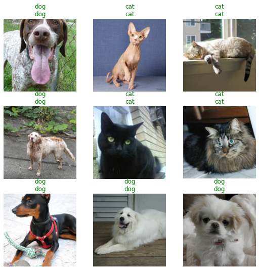

```python
learn.show_results()
```

### 오답분석

```python
interp = Interpretation.from_learner(learn)
```

[figure not shown]

```python
interp.plot_top_losses(16)
```

### 진짜 잘되는게 맞는지?

진짜 잘되는지 맞는지 우리집강아지 사진으로 테스트해보자.